# Lesson 1 - Análise exploratória de dados

Filipe Penati

24 de Junho, 2018

```r
load("analise-exploratoria-de-dados.RData")
```

# Data

Aqui está uma olhada em nossos dois data frames. O primeiro apresenta o registro de um experimento onde foi observado o peso de 50 pintinhos, nos 21 primeiros dias de vida, submetidos a 4 dietas diferentes. O segundo, é um subconjunto onde é apresentado o peso dos pintinhos ao final dos 21 dias. Apenas 45 dos 50 pintinhos foram acompanhados até 21º dia.

```r
head(data)
```

|  | weight | Time | Chick | Diet |
| --- | --- | --- | --- | --- |
| 1 | 42 | 0 | 1 | 1 |
| 2 | 51 | 2 | 1 | 1 |
| 3 | 59 | 4 | 1 | 1 |
| 4 | 64 | 6 | 1 | 1 |
| 5 | 76 | 8 | 1 | 1 |
| 6 | 93 | 10 | 1 | 1 |

```r
head(time_21)
```

|  | weight | Time | Chick | Diet |
| --- | --- | --- | --- | --- |
| 1 | 205 | 21 | 1 | 1 |
| 2 | 215 | 21 | 2 | 1 |
| 3 | 202 | 21 | 3 | 1 |
| 4 | 157 | 21 | 4 | 1 |
| 5 | 223 | 21 | 5 | 1 |
| 6 | 157 | 21 | 6 | 1 |

# Figures

Essa figura apresenta os registros do peso dos pintinhos de acordo com a dieta.

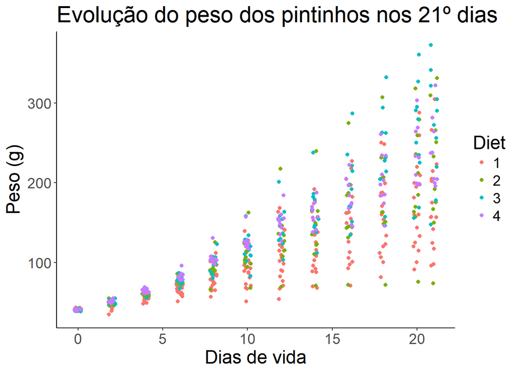

```r
data.plot
```

Aqui é apresentado a distribuição do peso dos pintinhos ao final dos 21 dias, de acordo com a dieta.

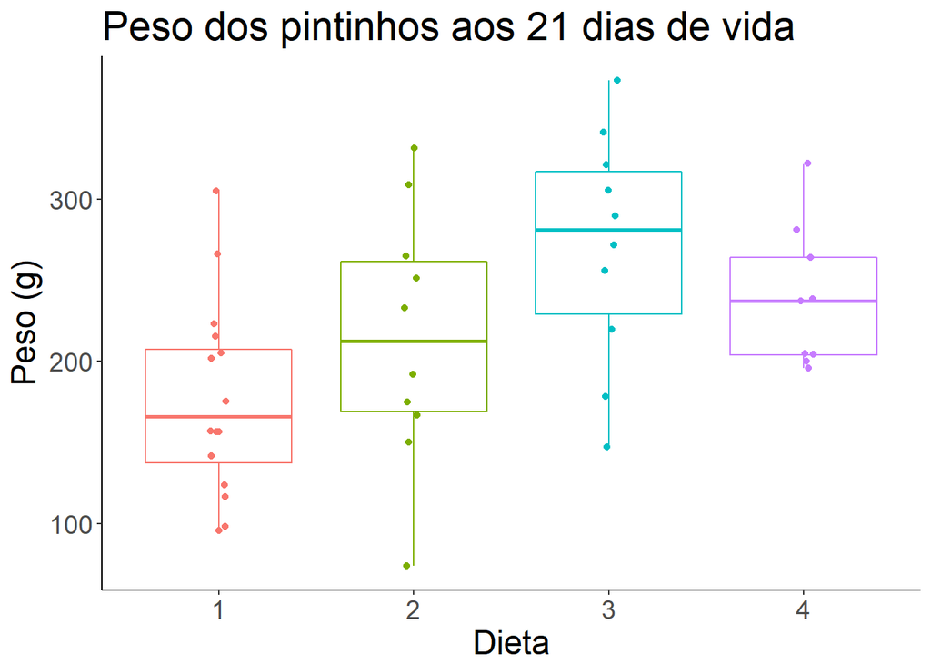

```r
time_21.plot
```

# Descriptive Statistics

Quando resumo da evolução do peso agrupando de acordo com os dias de vida, observamos como a variância aumenta com os dias. Podemos ver, com isso, a grande influência das dietas sobre o peso dos pintinhos.

```r
weight_by_time
```

| Time | weight_mean | weight_sd | weight_min | weight_max |
| --- | --- | --- | --- | --- |
| 0 | 41.06000 | 1.132272 | 39 | 43 |
| 2 | 49.22000 | 3.688316 | 35 | 55 |
| 4 | 59.95918 | 4.495179 | 48 | 69 |
| 6 | 74.30612 | 9.012038 | 51 | 96 |
| 8 | 91.24490 | 16.239780 | 57 | 131 |
| 10 | 107.83673 | 23.987277 | 51 | 163 |
| 12 | 129.24490 | 34.119600 | 54 | 217 |
| 14 | 143.81250 | 38.300412 | 68 | 240 |
| 16 | 168.08511 | 46.904079 | 71 | 287 |
| 18 | 190.19149 | 57.394757 | 72 | 332 |

[output cut: 2 more lines]

Quando olhamos o resumo do peso final dos pintinhos pelas 4 dietas, fica mais claro a diferença entre os resultados médios de cada dieta. Entretanto, ainda podemos ver um grande variabilidade nos resultados das dietas. A que se mostra mais consistente é a dieta “4”, apresentando um desvio médio de 43.3 gramas.

```r
weight_21days_by_diet
```

| Diet | weight_mean | weight_sd | weight_min | weight_max |
| --- | --- | --- | --- | --- |
| 1 | 177.7500 | 58.70207 | 96 | 305 |
| 2 | 214.7000 | 78.13813 | 74 | 331 |
| 3 | 270.3000 | 71.62254 | 147 | 373 |
| 4 | 238.5556 | 43.34775 | 196 | 322 |

Por fim, para evidenciar a diferença entre o comportamento das dietas ao longo dos 21 dias, foi desenhado o gráfico abaixo de acordo com as médias para cada dia e dieta.

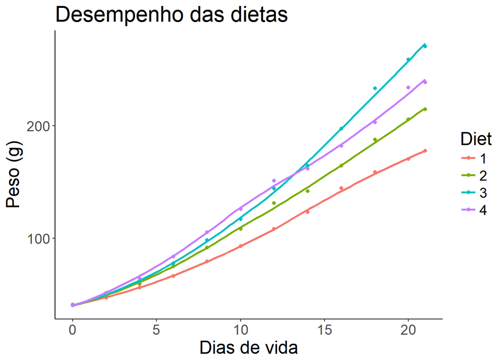

```r
weight_time_diet.plot
```